# Risk Factor Analysis

## Outcome Variable

**Outcome Variable:** wasted

## Predictor Variables

**Intervention Variable:** gagebrth

**Adjustment Set:**

unadjusted

## Stratifying Variables

The analysis was stratified on these variable(s):

- agecat
- studyid
- country

## Data Summary

| agecat | studyid | country | gagebrth | wasted | n_cell | n |
| --- | --- | --- | --- | --- | --- | --- |
| Birth | CMC-V-BCS-2002 | INDIA | Full or late term | 0 | 47 | 86 |
| Birth | CMC-V-BCS-2002 | INDIA | Full or late term | 1 | 6 | 86 |
| Birth | CMC-V-BCS-2002 | INDIA | Preterm | 0 | 8 | 86 |
| Birth | CMC-V-BCS-2002 | INDIA | Preterm | 1 | 3 | 86 |
| Birth | CMC-V-BCS-2002 | INDIA | Early term | 0 | 20 | 86 |
| Birth | CMC-V-BCS-2002 | INDIA | Early term | 1 | 2 | 86 |
| Birth | COHORTS | GUATEMALA | Full or late term | 0 | 240 | 572 |
| Birth | COHORTS | GUATEMALA | Full or late term | 1 | 83 | 572 |
| Birth | COHORTS | GUATEMALA | Preterm | 0 | 55 | 572 |
| Birth | COHORTS | GUATEMALA | Preterm | 1 | 23 | 572 |
| Birth | COHORTS | GUATEMALA | Early term | 0 | 131 | 572 |
| Birth | COHORTS | GUATEMALA | Early term | 1 | 40 | 572 |
| Birth | COHORTS | INDIA | Full or late term | 0 | 462 | 1229 |
| Birth | COHORTS | INDIA | Full or late term | 1 | 91 | 1229 |
| Birth | COHORTS | INDIA | Preterm | 0 | 205 | 1229 |
| Birth | COHORTS | INDIA | Preterm | 1 | 54 | 1229 |
| Birth | COHORTS | INDIA | Early term | 0 | 345 | 1229 |
| Birth | COHORTS | INDIA | Early term | 1 | 72 | 1229 |
| Birth | COHORTS | PHILIPPINES | Full or late term | 0 | 996 | 2874 |
| Birth | COHORTS | PHILIPPINES | Full or late term | 1 | 139 | 2874 |
| Birth | COHORTS | PHILIPPINES | Preterm | 0 | 467 | 2874 |
| Birth | COHORTS | PHILIPPINES | Preterm | 1 | 112 | 2874 |
| Birth | COHORTS | PHILIPPINES | Early term | 0 | 964 | 2874 |
| Birth | COHORTS | PHILIPPINES | Early term | 1 | 196 | 2874 |
| Birth | IRC | INDIA | Full or late term | 0 | 164 | 328 |
| Birth | IRC | INDIA | Full or late term | 1 | 49 | 328 |
| Birth | IRC | INDIA | Preterm | 0 | 19 | 328 |
| Birth | IRC | INDIA | Preterm | 1 | 13 | 328 |
| Birth | IRC | INDIA | Early term | 0 | 58 | 328 |
| Birth | IRC | INDIA | Early term | 1 | 25 | 328 |

[output cut: 126 more lines]

The following strata were considered:

- agecat: 24 months, studyid: CMC-V-BCS-2002, country: INDIA
- agecat: 24 months, studyid: COHORTS, country: GUATEMALA
- agecat: 24 months, studyid: COHORTS, country: INDIA
- agecat: 24 months, studyid: COHORTS, country: PHILIPPINES
- agecat: 24 months, studyid: IRC, country: INDIA
- agecat: 24 months, studyid: Keneba, country: GAMBIA
- agecat: 24 months, studyid: NIH-Crypto, country: BANGLADESH
- agecat: 24 months, studyid: PROBIT, country: BELARUS
- agecat: 24 months, studyid: TanzaniaChild2, country: TANZANIA, UNITED REPUBLIC OF
- agecat: 6 months, studyid: CMC-V-BCS-2002, country: INDIA
- agecat: 6 months, studyid: COHORTS, country: GUATEMALA
- agecat: 6 months, studyid: COHORTS, country: INDIA
- agecat: 6 months, studyid: COHORTS, country: PHILIPPINES
- agecat: 6 months, studyid: IRC, country: INDIA
- agecat: 6 months, studyid: Keneba, country: GAMBIA
- agecat: 6 months, studyid: NIH-Crypto, country: BANGLADESH
- agecat: 6 months, studyid: PROBIT, country: BELARUS
- agecat: 6 months, studyid: TanzaniaChild2, country: TANZANIA, UNITED REPUBLIC OF
- agecat: Birth, studyid: CMC-V-BCS-2002, country: INDIA
- agecat: Birth, studyid: COHORTS, country: GUATEMALA
- agecat: Birth, studyid: COHORTS, country: INDIA
- agecat: Birth, studyid: COHORTS, country: PHILIPPINES
- agecat: Birth, studyid: IRC, country: INDIA
- agecat: Birth, studyid: Keneba, country: GAMBIA
- agecat: Birth, studyid: NIH-Crypto, country: BANGLADESH
- agecat: Birth, studyid: PROBIT, country: BELARUS

### Dropped Strata

Some strata were dropped due to rare outcomes:

- agecat: Birth, studyid: CMC-V-BCS-2002, country: INDIA
- agecat: 6 months, studyid: COHORTS, country: GUATEMALA
- agecat: 6 months, studyid: NIH-Crypto, country: BANGLADESH
- agecat: 24 months, studyid: CMC-V-BCS-2002, country: INDIA
- agecat: 24 months, studyid: NIH-Crypto, country: BANGLADESH
- agecat: 24 months, studyid: PROBIT, country: BELARUS
- agecat: 24 months, studyid: TanzaniaChild2, country: TANZANIA, UNITED REPUBLIC OF

## Methods Detail

We’re interested in the causal parameters $E[Y_a]$ for all values of $a \in \mathcal{A}$. These parameters represent the mean outcome if, possibly contrary to fact, we intervened to set all units to have $A=a$. Under the randomization and positivity assumptions, these are identified by the statistical parameters $\psi_a=E_W[E_{Y|A,W}(Y|A=a,W)]$. In addition, we’re interested in the mean of $Y$, $E[Y]$ under no intervention (the observed mean). We will estimate these parameters by using SuperLearner to fit the relevant likelihood factors – $E_{Y|A,W}(Y|A=a,W)$ and $p(A=a|W)$, and then updating our likelihood fit using a joint TMLE.

For unadjusted analyses ($W=\{\}$), initial likelihoods were estimated using Lrnr_glm to estimate the simple $E(Y|A)$ and Lrnr_mean to estimate $p(A)$. For adjusted analyses, a small library containing Lrnr_glmnet, Lrnr_xgboost, and Lrnr_mean was used.

Having estimated these parameters, we will then use the delta method to estimate relative risks and attributable risks relative to a prespecified baseline level of $A$.

# Results Detail

## Results Plots

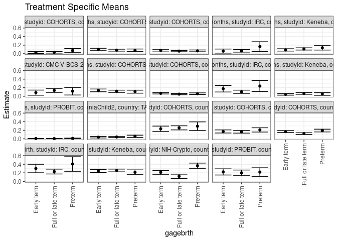

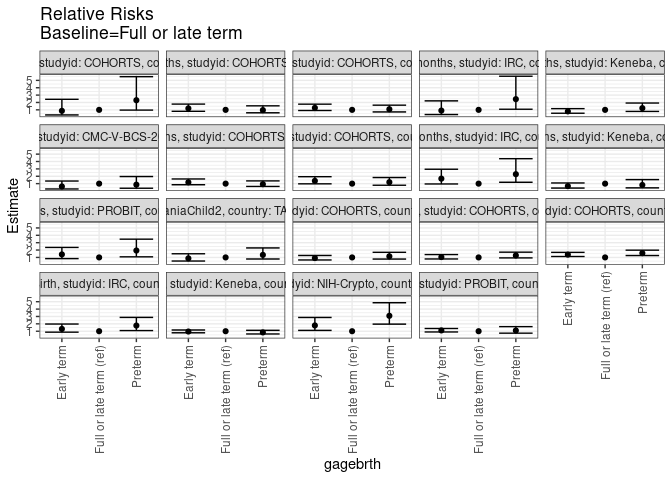

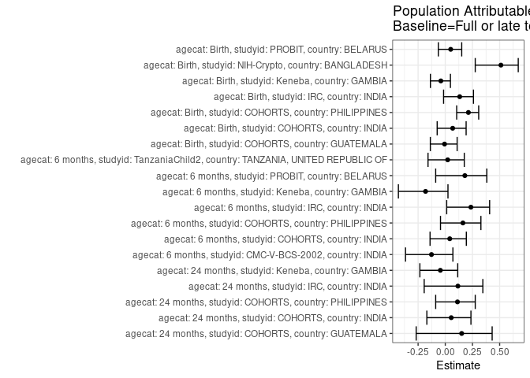

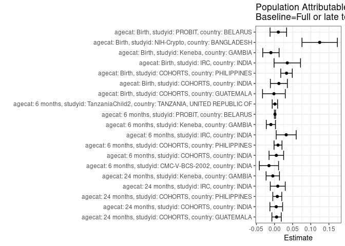

## Results Table

### Parameter: TSM

| agecat | studyid | country | intervention_level | baseline_level | estimate | ci_lower | ci_upper |
| --- | --- | --- | --- | --- | --- | --- | --- |
| Birth | COHORTS | GUATEMALA | Full or late term | NA | 0.2569659 | 0.2092714 | 0.3046605 |
| Birth | COHORTS | GUATEMALA | Preterm | NA | 0.2948718 | 0.1935900 | 0.3961536 |
| Birth | COHORTS | GUATEMALA | Early term | NA | 0.2339181 | 0.1704144 | 0.2974219 |
| Birth | COHORTS | INDIA | Full or late term | NA | 0.1645570 | 0.1336413 | 0.1954726 |
| Birth | COHORTS | INDIA | Preterm | NA | 0.2084942 | 0.1590006 | 0.2579878 |
| Birth | COHORTS | INDIA | Early term | NA | 0.1726619 | 0.1363711 | 0.2089527 |
| Birth | COHORTS | PHILIPPINES | Full or late term | NA | 0.1224670 | 0.1033919 | 0.1415421 |
| Birth | COHORTS | PHILIPPINES | Preterm | NA | 0.1934370 | 0.1612579 | 0.2256160 |
| Birth | COHORTS | PHILIPPINES | Early term | NA | 0.1689655 | 0.1473978 | 0.1905332 |
| Birth | IRC | INDIA | Full or late term | NA | 0.2300469 | 0.1734410 | 0.2866528 |
| Birth | IRC | INDIA | Preterm | NA | 0.4062500 | 0.2358245 | 0.5766755 |
| Birth | IRC | INDIA | Early term | NA | 0.3012048 | 0.2023545 | 0.4000551 |
| Birth | Keneba | GAMBIA | Full or late term | NA | 0.2552891 | 0.2231832 | 0.2873951 |
| Birth | Keneba | GAMBIA | Preterm | NA | 0.2135922 | 0.1576059 | 0.2695786 |
| Birth | Keneba | GAMBIA | Early term | NA | 0.2442748 | 0.2074742 | 0.2810754 |
| Birth | NIH-Crypto | BANGLADESH | Full or late term | NA | 0.1187500 | 0.0685895 | 0.1689105 |
| Birth | NIH-Crypto | BANGLADESH | Preterm | NA | 0.3666667 | 0.3056566 | 0.4276768 |
| Birth | NIH-Crypto | BANGLADESH | Early term | NA | 0.2117264 | 0.1659952 | 0.2574575 |
| Birth | PROBIT | BELARUS | Full or late term | NA | 0.1998585 | 0.1341432 | 0.2655737 |
| Birth | PROBIT | BELARUS | Preterm | NA | 0.2184154 | 0.1179151 | 0.3189158 |
| Birth | PROBIT | BELARUS | Early term | NA | 0.2214797 | 0.1495739 | 0.2933855 |
| 6 months | CMC-V-BCS-2002 | INDIA | Full or late term | NA | 0.1367925 | 0.0904694 | 0.1831155 |
| 6 months | CMC-V-BCS-2002 | INDIA | Preterm | NA | 0.1176471 | 0.0290941 | 0.2062000 |
| 6 months | CMC-V-BCS-2002 | INDIA | Early term | NA | 0.0843373 | 0.0244665 | 0.1442082 |
| 6 months | COHORTS | INDIA | Full or late term | NA | 0.1161972 | 0.0898330 | 0.1425614 |
| 6 months | COHORTS | INDIA | Preterm | NA | 0.1070234 | 0.0719694 | 0.1420774 |
| 6 months | COHORTS | INDIA | Early term | NA | 0.1370787 | 0.1051115 | 0.1690458 |
| 6 months | COHORTS | PHILIPPINES | Full or late term | NA | 0.0496109 | 0.0363348 | 0.0628870 |
| 6 months | COHORTS | PHILIPPINES | Preterm | NA | 0.0594406 | 0.0400600 | 0.0788211 |
| 6 months | COHORTS | PHILIPPINES | Early term | NA | 0.0682028 | 0.0531998 | 0.0832057 |
| 6 months | IRC | INDIA | Full or late term | NA | 0.1044177 | 0.0663857 | 0.1424496 |
| 6 months | IRC | INDIA | Preterm | NA | 0.2380952 | 0.1091191 | 0.3670714 |
| 6 months | IRC | INDIA | Early term | NA | 0.1752577 | 0.0995012 | 0.2510143 |
| 6 months | Keneba | GAMBIA | Full or late term | NA | 0.0653495 | 0.0464592 | 0.0842399 |
| 6 months | Keneba | GAMBIA | Preterm | NA | 0.0531401 | 0.0225715 | 0.0837087 |
| 6 months | Keneba | GAMBIA | Early term | NA | 0.0432220 | 0.0255492 | 0.0608948 |
| 6 months | PROBIT | BELARUS | Full or late term | NA | 0.0056208 | 0.0032178 | 0.0080238 |
| 6 months | PROBIT | BELARUS | Preterm | NA | 0.0108893 | 0.0042617 | 0.0175169 |
| 6 months | PROBIT | BELARUS | Early term | NA | 0.0079167 | 0.0057834 | 0.0100499 |
| 6 months | TanzaniaChild2 | TANZANIA, UNITED REPUBLIC OF | Full or late term | NA | 0.0437018 | 0.0319698 | 0.0554338 |
| 6 months | TanzaniaChild2 | TANZANIA, UNITED REPUBLIC OF | Preterm | NA | 0.0586207 | 0.0315767 | 0.0856647 |
| 6 months | TanzaniaChild2 | TANZANIA, UNITED REPUBLIC OF | Early term | NA | 0.0382022 | 0.0203880 | 0.0560165 |
| 24 months | COHORTS | GUATEMALA | Full or late term | NA | 0.0318302 | 0.0140966 | 0.0495639 |
| 24 months | COHORTS | GUATEMALA | Preterm | NA | 0.0733945 | 0.0244008 | 0.1223881 |
| 24 months | COHORTS | GUATEMALA | Early term | NA | 0.0276243 | 0.0037298 | 0.0515188 |
| 24 months | COHORTS | INDIA | Full or late term | NA | 0.0822898 | 0.0595003 | 0.1050793 |
| 24 months | COHORTS | INDIA | Preterm | NA | 0.0792079 | 0.0487879 | 0.1096279 |
| 24 months | COHORTS | INDIA | Early term | NA | 0.0986239 | 0.0706265 | 0.1266212 |
| 24 months | COHORTS | PHILIPPINES | Full or late term | NA | 0.0607029 | 0.0454268 | 0.0759789 |
| 24 months | COHORTS | PHILIPPINES | Preterm | NA | 0.0657640 | 0.0443935 | 0.0871345 |
| 24 months | COHORTS | PHILIPPINES | Early term | NA | 0.0771605 | 0.0603815 | 0.0939395 |
| 24 months | IRC | INDIA | Full or late term | NA | 0.0680000 | 0.0367537 | 0.0992463 |
| 24 months | IRC | INDIA | Preterm | NA | 0.1666667 | 0.0538133 | 0.2795201 |
| 24 months | IRC | INDIA | Early term | NA | 0.0612245 | 0.0136980 | 0.1087510 |
| 24 months | Keneba | GAMBIA | Full or late term | NA | 0.1111111 | 0.0850243 | 0.1371979 |
| 24 months | Keneba | GAMBIA | Preterm | NA | 0.1369048 | 0.0849028 | 0.1889067 |
| 24 months | Keneba | GAMBIA | Early term | NA | 0.0881671 | 0.0613872 | 0.1149469 |

### Parameter: E(Y)

| agecat | studyid | country | intervention_level | baseline_level | estimate | ci_lower | ci_upper |
| --- | --- | --- | --- | --- | --- | --- | --- |
| Birth | COHORTS | GUATEMALA | NA | NA | 0.2552448 | 0.2194833 | 0.2910062 |
| Birth | COHORTS | INDIA | NA | NA | 0.1765663 | 0.1552399 | 0.1978927 |
| Birth | COHORTS | PHILIPPINES | NA | NA | 0.1555324 | 0.1422803 | 0.1687844 |
| Birth | IRC | INDIA | NA | NA | 0.2652439 | 0.2173954 | 0.3130924 |
| Birth | Keneba | GAMBIA | NA | NA | 0.2453092 | 0.2230705 | 0.2675480 |
| Birth | NIH-Crypto | BANGLADESH | NA | NA | 0.2432815 | 0.2116319 | 0.2749310 |
| Birth | PROBIT | BELARUS | NA | NA | 0.2103206 | 0.1450833 | 0.2755580 |
| 6 months | CMC-V-BCS-2002 | INDIA | NA | NA | 0.1213873 | 0.0869266 | 0.1558480 |
| 6 months | COHORTS | INDIA | NA | NA | 0.1211890 | 0.1035235 | 0.1388545 |
| 6 months | COHORTS | PHILIPPINES | NA | NA | 0.0592179 | 0.0502884 | 0.0681474 |
| 6 months | IRC | INDIA | NA | NA | 0.1365979 | 0.1023826 | 0.1708133 |
| 6 months | Keneba | GAMBIA | NA | NA | 0.0553130 | 0.0432217 | 0.0674042 |
| 6 months | PROBIT | BELARUS | NA | NA | 0.0068541 | 0.0051915 | 0.0085167 |
| 6 months | TanzaniaChild2 | TANZANIA, UNITED REPUBLIC OF | NA | NA | 0.0446898 | 0.0354016 | 0.0539780 |
| 24 months | COHORTS | GUATEMALA | NA | NA | 0.0374813 | 0.0230560 | 0.0519065 |
| 24 months | COHORTS | INDIA | NA | NA | 0.0870570 | 0.0717143 | 0.1023997 |
| 24 months | COHORTS | PHILIPPINES | NA | NA | 0.0683690 | 0.0583283 | 0.0784097 |
| 24 months | IRC | INDIA | NA | NA | 0.0769231 | 0.0504429 | 0.1034032 |
| 24 months | Keneba | GAMBIA | NA | NA | 0.1063094 | 0.0885410 | 0.1240778 |

### Parameter: RR

| agecat | studyid | country | intervention_level | baseline_level | estimate | ci_lower | ci_upper |
| --- | --- | --- | --- | --- | --- | --- | --- |
| Birth | COHORTS | GUATEMALA | Full or late term | Full or late term | 1.0000000 | 1.0000000 | 1.000000 |
| Birth | COHORTS | GUATEMALA | Preterm | Full or late term | 1.1475131 | 0.7766066 | 1.695564 |
| Birth | COHORTS | GUATEMALA | Early term | Full or late term | 0.9103079 | 0.6551869 | 1.264770 |
| Birth | COHORTS | INDIA | Full or late term | Full or late term | 1.0000000 | 1.0000000 | 1.000000 |
| Birth | COHORTS | INDIA | Preterm | Full or late term | 1.2670033 | 0.9360561 | 1.714958 |
| Birth | COHORTS | INDIA | Early term | Full or late term | 1.0492529 | 0.7914949 | 1.390952 |
| Birth | COHORTS | PHILIPPINES | Full or late term | Full or late term | 1.0000000 | 1.0000000 | 1.000000 |
| Birth | COHORTS | PHILIPPINES | Preterm | Full or late term | 1.5795032 | 1.2576187 | 1.983773 |
| Birth | COHORTS | PHILIPPINES | Early term | Full or late term | 1.3796825 | 1.1280315 | 1.687474 |
| Birth | IRC | INDIA | Full or late term | Full or late term | 1.0000000 | 1.0000000 | 1.000000 |
| Birth | IRC | INDIA | Preterm | Full or late term | 1.7659439 | 1.0858219 | 2.872071 |
| Birth | IRC | INDIA | Early term | Full or late term | 1.3093189 | 0.8687701 | 1.973268 |
| Birth | Keneba | GAMBIA | Full or late term | Full or late term | 1.0000000 | 1.0000000 | 1.000000 |
| Birth | Keneba | GAMBIA | Preterm | Full or late term | 0.8366679 | 0.6255932 | 1.118959 |
| Birth | Keneba | GAMBIA | Early term | Full or late term | 0.9568555 | 0.7863534 | 1.164327 |
| Birth | NIH-Crypto | BANGLADESH | Full or late term | Full or late term | 1.0000000 | 1.0000000 | 1.000000 |
| Birth | NIH-Crypto | BANGLADESH | Preterm | Full or late term | 3.0877193 | 1.9609673 | 4.861892 |
| Birth | NIH-Crypto | BANGLADESH | Early term | Full or late term | 1.7829590 | 1.1094349 | 2.865371 |
| Birth | PROBIT | BELARUS | Full or late term | Full or late term | 1.0000000 | 1.0000000 | 1.000000 |
| Birth | PROBIT | BELARUS | Preterm | Full or late term | 1.0928505 | 0.7361128 | 1.622472 |
| Birth | PROBIT | BELARUS | Early term | Full or late term | 1.1081828 | 0.8992782 | 1.365617 |
| 6 months | CMC-V-BCS-2002 | INDIA | Full or late term | Full or late term | 1.0000000 | 1.0000000 | 1.000000 |
| 6 months | CMC-V-BCS-2002 | INDIA | Preterm | Full or late term | 0.8600406 | 0.3767610 | 1.963234 |
| 6 months | CMC-V-BCS-2002 | INDIA | Early term | Full or late term | 0.6165351 | 0.2807839 | 1.353765 |
| 6 months | COHORTS | INDIA | Full or late term | Full or late term | 1.0000000 | 1.0000000 | 1.000000 |
| 6 months | COHORTS | INDIA | Preterm | Full or late term | 0.9210500 | 0.6183581 | 1.371912 |
| 6 months | COHORTS | INDIA | Early term | Full or late term | 1.1797072 | 0.8520579 | 1.633350 |
| 6 months | COHORTS | PHILIPPINES | Full or late term | Full or late term | 1.0000000 | 1.0000000 | 1.000000 |
| 6 months | COHORTS | PHILIPPINES | Preterm | Full or late term | 1.1981352 | 0.7858104 | 1.826812 |
| 6 months | COHORTS | PHILIPPINES | Early term | Full or late term | 1.3747538 | 0.9722542 | 1.943882 |
| 6 months | IRC | INDIA | Full or late term | Full or late term | 1.0000000 | 1.0000000 | 1.000000 |
| 6 months | IRC | INDIA | Preterm | Full or late term | 2.2802198 | 1.1870927 | 4.379946 |
| 6 months | IRC | INDIA | Early term | Full or late term | 1.6784298 | 0.9537122 | 2.953854 |
| 6 months | Keneba | GAMBIA | Full or late term | Full or late term | 1.0000000 | 1.0000000 | 1.000000 |
| 6 months | Keneba | GAMBIA | Preterm | Full or late term | 0.8131671 | 0.4271548 | 1.548012 |
| 6 months | Keneba | GAMBIA | Early term | Full or late term | 0.6613972 | 0.4008590 | 1.091272 |
| 6 months | PROBIT | BELARUS | Full or late term | Full or late term | 1.0000000 | 1.0000000 | 1.000000 |
| 6 months | PROBIT | BELARUS | Preterm | Full or late term | 1.9373261 | 1.0788654 | 3.478870 |
| 6 months | PROBIT | BELARUS | Early term | Full or late term | 1.4084630 | 0.8413101 | 2.357951 |
| 6 months | TanzaniaChild2 | TANZANIA, UNITED REPUBLIC OF | Full or late term | Full or late term | 1.0000000 | 1.0000000 | 1.000000 |
| 6 months | TanzaniaChild2 | TANZANIA, UNITED REPUBLIC OF | Preterm | Full or late term | 1.3413793 | 0.7865774 | 2.287504 |
| 6 months | TanzaniaChild2 | TANZANIA, UNITED REPUBLIC OF | Early term | Full or late term | 0.8741573 | 0.5103980 | 1.497167 |
| 24 months | COHORTS | GUATEMALA | Full or late term | Full or late term | 1.0000000 | 1.0000000 | 1.000000 |
| 24 months | COHORTS | GUATEMALA | Preterm | Full or late term | 2.3058104 | 0.9665200 | 5.500933 |
| 24 months | COHORTS | GUATEMALA | Early term | Full or late term | 0.8678637 | 0.3101816 | 2.428214 |
| 24 months | COHORTS | INDIA | Full or late term | Full or late term | 1.0000000 | 1.0000000 | 1.000000 |
| 24 months | COHORTS | INDIA | Preterm | Full or late term | 0.9625484 | 0.5994987 | 1.545457 |
| 24 months | COHORTS | INDIA | Early term | Full or late term | 1.1984942 | 0.8061178 | 1.781859 |
| 24 months | COHORTS | PHILIPPINES | Full or late term | Full or late term | 1.0000000 | 1.0000000 | 1.000000 |
| 24 months | COHORTS | PHILIPPINES | Preterm | Full or late term | 1.0833758 | 0.7182593 | 1.634094 |
| 24 months | COHORTS | PHILIPPINES | Early term | Full or late term | 1.2711176 | 0.9114731 | 1.772669 |
| 24 months | IRC | INDIA | Full or late term | Full or late term | 1.0000000 | 1.0000000 | 1.000000 |
| 24 months | IRC | INDIA | Preterm | Full or late term | 2.4509804 | 1.0813122 | 5.555569 |
| 24 months | IRC | INDIA | Early term | Full or late term | 0.9003601 | 0.3653015 | 2.219121 |
| 24 months | Keneba | GAMBIA | Full or late term | Full or late term | 1.0000000 | 1.0000000 | 1.000000 |
| 24 months | Keneba | GAMBIA | Preterm | Full or late term | 1.2321429 | 0.7883692 | 1.925717 |
| 24 months | Keneba | GAMBIA | Early term | Full or late term | 0.7935035 | 0.5405335 | 1.164864 |

### Parameter: PAR

| agecat | studyid | country | intervention_level | baseline_level | estimate | ci_lower | ci_upper |
| --- | --- | --- | --- | --- | --- | --- | --- |
| Birth | COHORTS | GUATEMALA | Full or late term | NA | -0.0017212 | -0.0330994 | 0.0296570 |
| Birth | COHORTS | INDIA | Full or late term | NA | 0.0120094 | -0.0114527 | 0.0354715 |
| Birth | COHORTS | PHILIPPINES | Full or late term | NA | 0.0330654 | 0.0171882 | 0.0489426 |
| Birth | IRC | INDIA | Full or late term | NA | 0.0351970 | -0.0013013 | 0.0716952 |
| Birth | Keneba | GAMBIA | Full or late term | NA | -0.0099799 | -0.0325543 | 0.0125945 |
| Birth | NIH-Crypto | BANGLADESH | Full or late term | NA | 0.1245315 | 0.0757570 | 0.1733060 |
| Birth | PROBIT | BELARUS | Full or late term | NA | 0.0104622 | -0.0123831 | 0.0333075 |
| 6 months | CMC-V-BCS-2002 | INDIA | Full or late term | NA | -0.0154052 | -0.0419343 | 0.0111240 |
| 6 months | COHORTS | INDIA | Full or late term | NA | 0.0049918 | -0.0151405 | 0.0251242 |
| 6 months | COHORTS | PHILIPPINES | Full or late term | NA | 0.0096070 | -0.0013942 | 0.0206082 |
| 6 months | IRC | INDIA | Full or late term | NA | 0.0321803 | 0.0046009 | 0.0597596 |
| 6 months | Keneba | GAMBIA | Full or late term | NA | -0.0100366 | -0.0227354 | 0.0026623 |
| 6 months | PROBIT | BELARUS | Full or late term | NA | 0.0012333 | -0.0002880 | 0.0027547 |
| 6 months | TanzaniaChild2 | TANZANIA, UNITED REPUBLIC OF | Full or late term | NA | 0.0009880 | -0.0064288 | 0.0084048 |
| 24 months | COHORTS | GUATEMALA | Full or late term | NA | 0.0056510 | -0.0072744 | 0.0185765 |
| 24 months | COHORTS | INDIA | Full or late term | NA | 0.0047672 | -0.0127662 | 0.0223006 |
| 24 months | COHORTS | PHILIPPINES | Full or late term | NA | 0.0076662 | -0.0047305 | 0.0200628 |
| 24 months | IRC | INDIA | Full or late term | NA | 0.0089231 | -0.0117124 | 0.0295586 |
| 24 months | Keneba | GAMBIA | Full or late term | NA | -0.0048017 | -0.0232362 | 0.0136328 |

### Parameter: PAF

| agecat | studyid | country | intervention_level | baseline_level | estimate | ci_lower | ci_upper |
| --- | --- | --- | --- | --- | --- | --- | --- |
| Birth | COHORTS | GUATEMALA | Full or late term | NA | -0.0067433 | -0.1374967 | 0.1089803 |
| Birth | COHORTS | INDIA | Full or late term | NA | 0.0680161 | -0.0746274 | 0.1917254 |
| Birth | COHORTS | PHILIPPINES | Full or late term | NA | 0.2125950 | 0.1049048 | 0.3073288 |
| Birth | IRC | INDIA | Full or late term | NA | 0.1326966 | -0.0155082 | 0.2592721 |
| Birth | Keneba | GAMBIA | Full or late term | NA | -0.0406829 | -0.1368725 | 0.0473681 |
| Birth | NIH-Crypto | BANGLADESH | Full or late term | NA | 0.5118823 | 0.2755326 | 0.6711254 |
| Birth | PROBIT | BELARUS | Full or late term | NA | 0.0497439 | -0.0638844 | 0.1512361 |
| 6 months | CMC-V-BCS-2002 | INDIA | Full or late term | NA | -0.1269093 | -0.3655987 | 0.0700603 |
| 6 months | COHORTS | INDIA | Full or late term | NA | 0.0411905 | -0.1400978 | 0.1936520 |
| 6 months | COHORTS | PHILIPPINES | Full or late term | NA | 0.1622311 | -0.0439488 | 0.3276905 |
| 6 months | IRC | INDIA | Full or late term | NA | 0.2355838 | 0.0131261 | 0.4078959 |
| 6 months | Keneba | GAMBIA | Full or late term | NA | -0.1814510 | -0.4312528 | 0.0247520 |
| 6 months | PROBIT | BELARUS | Full or late term | NA | 0.1799380 | -0.0882413 | 0.3820289 |
| 6 months | TanzaniaChild2 | TANZANIA, UNITED REPUBLIC OF | Full or late term | NA | 0.0221080 | -0.1587005 | 0.1747024 |
| 24 months | COHORTS | GUATEMALA | Full or late term | NA | 0.1507692 | -0.2677534 | 0.4311253 |
| 24 months | COHORTS | INDIA | Full or late term | NA | 0.0547596 | -0.1694723 | 0.2359978 |
| 24 months | COHORTS | PHILIPPINES | Full or late term | NA | 0.1121290 | -0.0882338 | 0.2756015 |
| 24 months | IRC | INDIA | Full or late term | NA | 0.1160000 | -0.1939710 | 0.3454983 |
| 24 months | Keneba | GAMBIA | Full or late term | NA | -0.0451671 | -0.2336403 | 0.1145115 |